# Statistical Modeling and Inference - Seminar 5

Paul Rognon and Geert Mesters

```r
knitr::opts_chunk$set(message= FALSE, warning = FALSE)
```

In this seminar we will work on topic modeling. We will see how to preprocess texts and run a Latent Dirichlet Allocation model. We will use a subset of the CORD-19 dataset: an extensive collection of scholarly articles related to COVID-19 gathered by the Allen Institute for AI in collaboration with the US Government. CORD-19 dataset was part of a call to action to the world’s artificial intelligence experts to develop text and data mining tools that can help the medical community in the fight against the disease. It was published on Kaggle in 2019 and one of the winners used Latent Dirichlet Allocation.

```r
# install.packages(c("quanteda","quanteda.textplots","stm","lda", "servr", "cld3"))
library(readr)
library(tidyverse)
library(quanteda) # quantitative analysis of textual data  (https://quanteda.io/articles/quickstart.html)
library(quanteda.textplots) # complementary to quanteda, for visualization
library(cld3) # for language detection
library(lda) # implementation of Latent Dirichlet Allocation
library(servr) # will be used for visualization
# library(topicmodels) # alternative to lda, several topic models included
library(stm) # for structural topic modeling
set.seed(5528) # set seed for reproductibility
PATH= 'C:/Users/paulr/Documents/PhD/teaching/StatInference/seminar5'
```

We load the metada of the articles. This metadata contains article abstracts. We will work directly on abstracts instead of full-length articles because they capture the essence of the publications while being much shorter, thus limiting computation time and complexity.

```r
metadata <- read_csv(file.path(PATH,"data/metadata.csv"))
```

# 1 Data exploration, cleaning and preprocessing

## 1.1 Duplicates and subset

There are more than 480 000 records in the collection, each identified by a CORD-UID number. We see that there is a large number of repeated CORD-UID numbers.

```r
nrow(metadata)
```

```
## [1] 482221
```

```r
length(unique(metadata$cord_uid))
```

```
## [1] 457294
```

We remove the repeated entries (repeated CORD-UID and repeated abstracts) and sample 10 000 abstracts that will form our subset.

```r
metadata_unique_20000 <- metadata %>% distinct(cord_uid, .keep_all = TRUE) %>% distinct(abstract, .keep_all = TRUE) %>% slice(sample(1:n(),10000))
```

## 1.2 Corpus object

We create a `corpus` object from the collection of 10 000 abstracts. `corpus` is a matrix-like class of objects from the `quanteda` package.

```r
covidCorpus <- corpus(metadata_unique_20000, docid_field = 'cord_uid', text_field = 'abstract')
```

## 1.3 Language detection

The collection of texts we have has the particularity to contain publications in many different languages. We use the language detection package `cld3` to identify and retain only abstracts in English.

```r
languages <- detect_language(covidCorpus)
table(languages)
```

```
## languages
##   az   cs   da   de   el   en   es   fr   hu   it   nl   ny   pt   ru   zh
##    1    1    1   24    2 9783   56   33    1    3    8    1   43    7    9
```

## 1.4 Abstract length

```r
covidCorpus <- subset(covidCorpus, languages == "en")
```

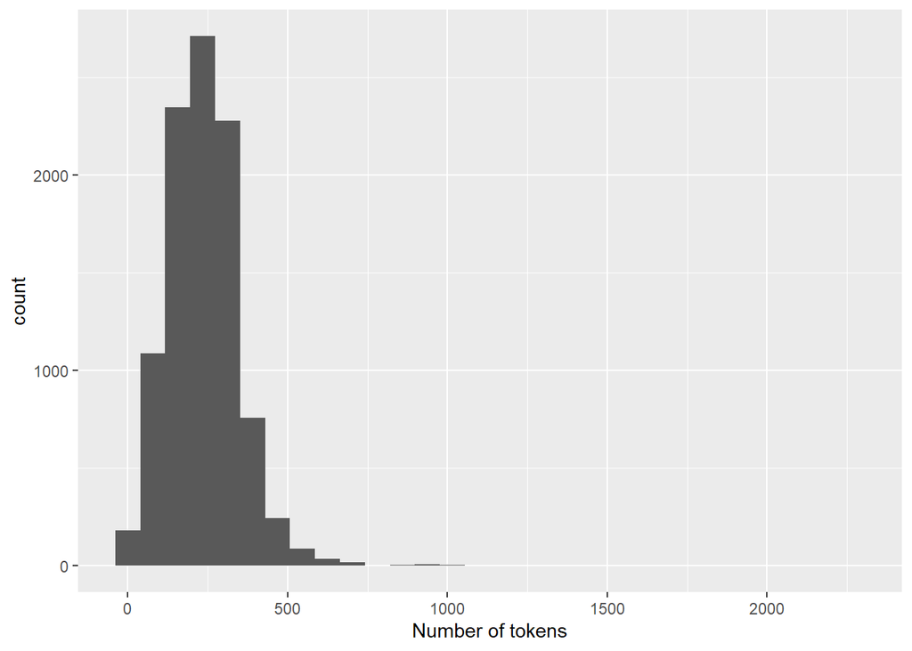

```r
ntokens_corpus <- ntoken(covidCorpus)
data.frame(ntokens_corpus) %>% ggplot(aes(ntokens_corpus)) + geom_histogram() + xlab('Number of tokens')
```

We retain only documents with a length between 50 and 400.

```r
docs_length50_400 <- names(ntokens_corpus[(ntokens_corpus>=50) & (ntokens_corpus<=400)])
covidCorpus_filtered <- covidCorpus[names(covidCorpus) %in% docs_length50_400]
```

## 1.5 Tokenization and more filtering of abstract

The next step of our pre-processing is to divide a text into tokens. To do that, we use the function `tokens` from `quanteda` package.

```r
covidCorpus_tokenized <- tokens(covidCorpus)
```

Our collection of articles contains articles about COVID-19 but also adjacent topics, not directly linked to COVID-19. To narrow down the topics in the collection, we retain only the articles that contain tokens “COVID-19”,“COVID”,“SARS” or “SARS-COV-2”.

```r
res<-kwic(covidCorpus_tokenized, pattern = c("COVID-19","COVID","SARS","SARS-COV-2"), case_insensitive=FALSE)
length(unique(res$docname))
```

```
## [1] 4691
```

```r
docs_aboutcovid <- unique(res$docname)
covidCorpus_filtered <- covidCorpus_filtered[names(covidCorpus_filtered) %in% docs_aboutcovid]
```

We plot again the article lengths in our corpus and we see it is now more equally distributed.

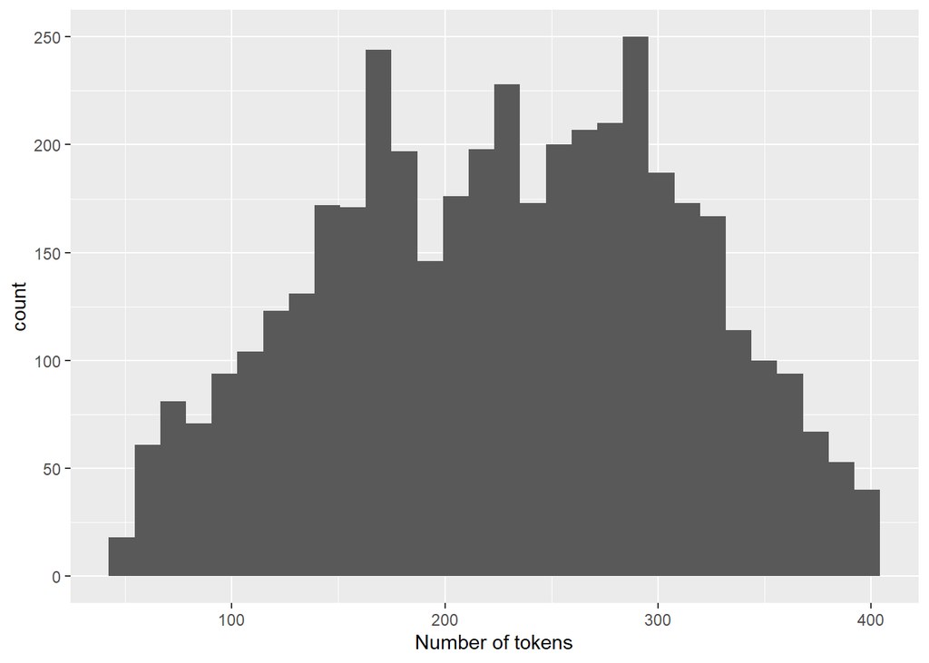

```r
ntokens_corpus_filtered <- ntoken(covidCorpus_filtered)
data.frame(ntokens_corpus_filtered) %>% ggplot(aes(ntokens_corpus_filtered)) + geom_histogram() + xlab('Number of tokens')
```

## 1.6 Features extraction or representation learning

The next step in our preprocessing is to extract numerical features from our corpus. We convert our tokenized corpus into a document$\times$term frequency where we have the documents in rows and one feature for each token present in our corpus (our vocabulary). The matrix entries are the frequency of a given token in a given document. 99.64% of the matrix entries are 0s. We use the function `tokens` followed by the function `dfm`. Note that `quanteda` accepts `tydiverse` syntax.

```r
covidCorpus_filtered_tokenized <- tokens(covidCorpus_filtered)
dfm_covidCorpus_filtered<- dfm(covidCorpus_filtered_tokenized)
dfm_covidCorpus_filtered
```

```
## Document-feature matrix of: 4,250 documents, 35,061 features (99.64% sparse) and 17 docvars.
##           features
## docs       rationing of medical resources is  a critical issue in the
##   j0vx5s7v         2  9       3         3  4 14        1     1  7   9
##   u2rtk2aw         0  5       0         0  2  5        0     0  1   8
##   7ehp3a6l         0  7       0         0  3  4        0     0  3  18
##   h23iqb7s         0  9       0         0  3  0        0     0  4  14
##   4qhvljpv         0  9       0         1  1  7        0     0  4  11
##   xm3onn5u         0  2       1         0  0  0        0     0  0   5
## [ reached max_ndoc ... 4,244 more documents, reached max_nfeat ... 35,051 more features ]
```

```r
# equivalently
# dfm_covidCorpus_filtered<- tokens(covidCorpus_filtered) %>%  dfm()
```

A nice visualization of tokens frequency are word clouds: the most frequent tokens are plotted with a size proportional to their frequency in the corpus. We see below that the most frequent tokens are words that carry little information such that ‘the’, ‘and’, ‘of’ and also punctuation signs.

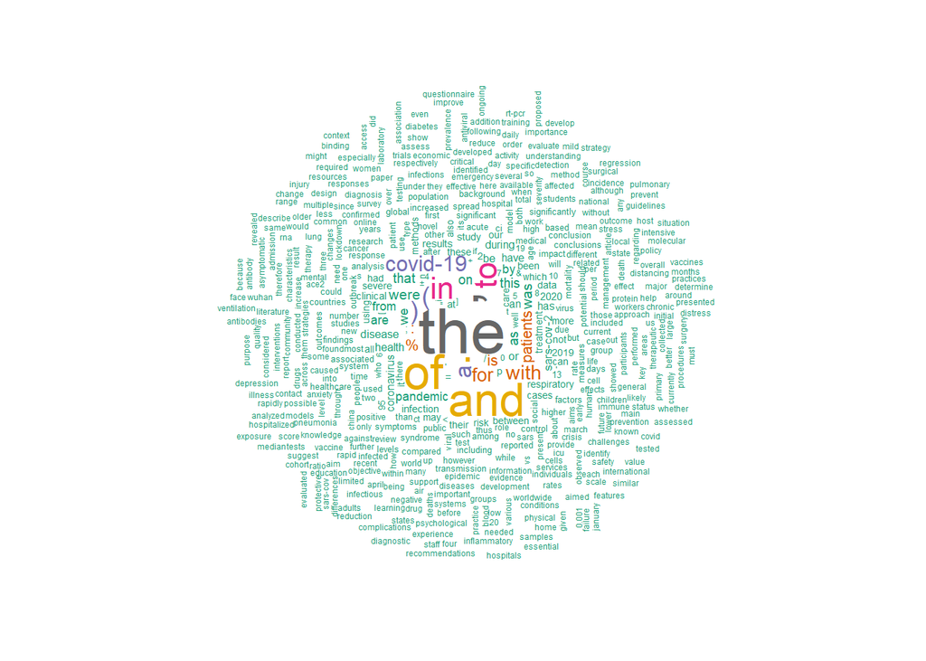

```r
textplot_wordcloud(dfm_covidCorpus_filtered, random_order = FALSE, rotation = 0.25,
    color = RColorBrewer::brewer.pal(8, "Dark2"))
```

## 1.7 Stop words and punctuation

Very common words that carry little information are called stop words and we will remove them from corpus. The `quanteda` package provides lists of stop words for some language including English. We append to this list words that can be considered as stop words in our context because they do not carry differential information: ‘COVID-19’, ‘disease’ or units of measure.

```r
head(stopwords("en"), 50)
```

```
##  [1] "i"          "me"         "my"         "myself"     "we"
##  [6] "our"        "ours"       "ourselves"  "you"        "your"
## [11] "yours"      "yourself"   "yourselves" "he"         "him"
## [16] "his"        "himself"    "she"        "her"        "hers"
## [21] "herself"    "it"         "its"        "itself"     "they"
## [26] "them"       "their"      "theirs"     "themselves" "what"
## [31] "which"      "who"        "whom"       "this"       "that"
## [36] "these"      "those"      "am"         "is"         "are"
## [41] "was"        "were"       "be"         "been"       "being"
## [46] "have"       "has"        "had"        "having"     "do"
```

```r
custom_list_stopwords <- read_csv(file.path(PATH,"data/list_stopwords.csv"),
    col_types = cols(X1 = col_skip()))
head(custom_list_stopwords,5)
```

```
## # A tibble: 5 x 1
##   stop_words
##   <chr>
## 1 covid
## 2 19
## 3 95
## 4 ci
## 5 cov
```

```r
custom_list_stopwords <- c(custom_list_stopwords$stop_words,stopwords("en"), 'also', 'may','can')
```

We rebuild our document$\times$term frequency matrix removing punctuation signs, symbols, numbers, and stop words and obtain a more sensible word cloud.

```r
dfm_covidCorpus_filtered2 <- tokens(covidCorpus_filtered, remove_punct = TRUE,
                                          remove_symbols = TRUE, remove_numbers = TRUE) %>%
                            tokens_remove(custom_list_stopwords) %>%
                            dfm() %>%
                            dfm_tolower()
dfm_covidCorpus_filtered2
```

```
## Document-feature matrix of: 4,250 documents, 30,366 features (99.75% sparse) and 17 docvars.
##           features
## docs       rationing medical resources critical issue existing triage protocols
##   j0vx5s7v         2       3         3        1     1        1      3         2
##   u2rtk2aw         0       0         0        0     0        0      0         0
##   7ehp3a6l         0       0         0        0     0        0      0         0
##   h23iqb7s         0       0         0        0     0        0      0         0
##   4qhvljpv         0       0         1        0     0        0      0         0
##   xm3onn5u         0       1         0        0     0        0      0         0
##           features
## docs       priority point
##   j0vx5s7v        6     3
##   u2rtk2aw        0     0
##   7ehp3a6l        1     0
##   h23iqb7s        0     0
##   4qhvljpv        0     0
##   xm3onn5u        0     0
## [ reached max_ndoc ... 4,244 more documents, reached max_nfeat ... 30,356 more features ]
```

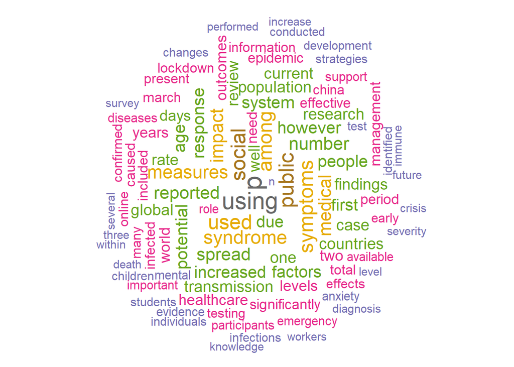

```r
textplot_wordcloud(dfm_covidCorpus_filtered2, random_order = FALSE, rotation = 0.25,
    color = RColorBrewer::brewer.pal(8, "Dark2"),max_words =100,max_size = 3)
```

## 1.8 Stemming

```r
dfm_covidCorpus_filtered3 <- tokens(covidCorpus_filtered, remove_punct = TRUE,
                                          remove_symbols = TRUE, remove_numbers = TRUE) %>%
                            tokens_remove(custom_list_stopwords) %>%
                            tokens_wordstem() %>%
                            dfm() %>%
                            dfm_tolower()
dfm_covidCorpus_filtered3
```

```
## Document-feature matrix of: 4,250 documents, 22,749 features (99.69% sparse) and 17 docvars.
##           features
## docs       ration medic resourc critic issu exist triag protocol prioriti point
##   j0vx5s7v      3     3       4      1    1     1     3        3        7     3
##   u2rtk2aw      0     0       0      0    0     0     0        0        0     0
##   7ehp3a6l      0     0       0      0    0     0     0        0        1     0
##   h23iqb7s      0     0       0      0    0     0     0        0        0     0
##   4qhvljpv      0     0       1      0    0     0     0        0        0     0
##   xm3onn5u      0     1       0      0    0     1     0        0        0     0
## [ reached max_ndoc ... 4,244 more documents, reached max_nfeat ... 22,739 more features ]
```

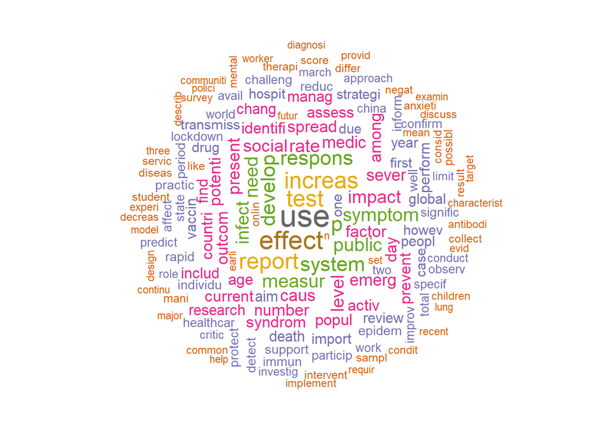

```r
textplot_wordcloud(dfm_covidCorpus_filtered3, random_order = FALSE, rotation = 0.25,
    color = RColorBrewer::brewer.pal(8, "Dark2"),max_words =150,max_size = 3)
```

## 1.9 $n$-grams

When extracting features from a text, an important consideration is that words do not come alone. Words context have a big impact on their meaning. ‘Science’ and ‘data’ alone have very different meaning from ‘Data Science’.

A group of $n$ tokens is called a $n$-gram. We will include among our features all single words and pairs of words with the `tokens_ngrams` function. The dimensionality of our matrix greatly increases.

```r
dfm_covidCorpus_filtered4 <- tokens(covidCorpus_filtered, remove_punct = TRUE,
                                          remove_symbols = TRUE, remove_numbers = TRUE) %>%
                            tokens_remove(custom_list_stopwords) %>%
                            tokens_wordstem() %>%
                            tokens_ngrams(n = c(1, 2)) %>%
                            dfm() %>%
                            dfm_tolower()
dfm_covidCorpus_filtered4
```

```
## Document-feature matrix of: 4,250 documents, 299,255 features (99.95% sparse) and 17 docvars.
##           features
## docs       ration medic resourc critic issu exist triag protocol prioriti point
##   j0vx5s7v      3     3       4      1    1     1     3        3        7     3
##   u2rtk2aw      0     0       0      0    0     0     0        0        0     0
##   7ehp3a6l      0     0       0      0    0     0     0        0        1     0
##   h23iqb7s      0     0       0      0    0     0     0        0        0     0
##   4qhvljpv      0     0       1      0    0     0     0        0        0     0
##   xm3onn5u      0     1       0      0    0     1     0        0        0     0
## [ reached max_ndoc ... 4,244 more documents, reached max_nfeat ... 299,245 more features ]
```

## 1.10 Infrequent terms

Finally, very rare terms do not carry valuable information and add noise when we are trying to extract common topics in the corpus, so we will remove them as well with the function `dfm_trim`. We see that we obtain now a smaller and slightly less sparse matrix.

```r
dfm_covidCorpus_filtered_final <- tokens(covidCorpus_filtered, remove_punct = TRUE,
                                          remove_symbols = TRUE, remove_numbers = TRUE) %>%
                            tokens_remove(custom_list_stopwords) %>%
                            tokens_wordstem() %>%
                            tokens_ngrams(n = c(1, 2)) %>%
                            dfm() %>%
                            dfm_tolower() %>%
                            dfm_trim(min_termfreq = 5, min_docfreq = 0.0025, docfreq_type = "prop")
dfm_covidCorpus_filtered_final
```

```
## Document-feature matrix of: 4,250 documents, 4,618 features (98.49% sparse) and 17 docvars.
##           features
## docs       ration medic resourc critic issu exist triag protocol prioriti point
##   j0vx5s7v      3     3       4      1    1     1     3        3        7     3
##   u2rtk2aw      0     0       0      0    0     0     0        0        0     0
##   7ehp3a6l      0     0       0      0    0     0     0        0        1     0
##   h23iqb7s      0     0       0      0    0     0     0        0        0     0
##   4qhvljpv      0     0       1      0    0     0     0        0        0     0
##   xm3onn5u      0     1       0      0    0     1     0        0        0     0
## [ reached max_ndoc ... 4,244 more documents, reached max_nfeat ... 4,608 more features ]
```

With the function `topfeatures` we can extract the most frequent terms in our document$\times$term frequency matrix.

```r
topfeatures(dfm_covidCorpus_filtered_final, 20)
```

```
##     use  effect    test increas  report       p develop  system respons  public
##    2332    1877    1632    1626    1577    1398    1379    1365    1359    1212
##  measur symptom    need  infect   level  impact    rate  social    caus   emerg
##    1204    1200    1193    1183    1160    1136    1128    1078    1061    1059
```

## 1.11 TF-IDF

Latent Dirichlet Allocation takes as input a document$\times$term frequency matrix. However, another popular representation of a corpus is a TF-IDF matrix which has the same structure as a document$\times$term frequency matrix but the term frequencies (TF) are weighted by the inverse document frequency (IDF). The IDF is the inverse of the number of documents in which the term occurs, log scaled. The objective is to downscale the matrix entries of frequent terms in the corpus and upscale the matrix entries of terms specific to a group of documents.

```r
dfm_covidCorpus_filtered_tfidf <- tokens(covidCorpus_filtered, remove_punct = TRUE,
                                          remove_symbols = TRUE, remove_numbers = TRUE) %>%
                            tokens_remove(custom_list_stopwords) %>%
                            tokens_wordstem() %>%
                            tokens_ngrams(n = c(1, 2)) %>%
                            dfm() %>%
                            dfm_tolower() %>%
                            dfm_trim(min_termfreq = 5, min_docfreq = 0.0025, docfreq_type = "prop") %>%
                            dfm_tfidf()

dfm_covidCorpus_filtered_tfidf
```

```
## Document-feature matrix of: 4,250 documents, 4,618 features (98.49% sparse) and 17 docvars.
##           features
## docs         ration     medic  resourc    critic     issu    exist    triag
##   j0vx5s7v 6.015419 2.4975267 4.576356 0.9989793 1.216769 1.240999 5.277472
##   u2rtk2aw 0        0         0        0         0        0        0
##   7ehp3a6l 0        0         0        0         0        0        0
##   h23iqb7s 0        0         0        0         0        0        0
##   4qhvljpv 0        0         1.144089 0         0        0        0
##   xm3onn5u 0        0.8325089 0        0         0        1.240999 0
##           features
## docs       protocol  prioriti   point
##   j0vx5s7v 4.305793 11.965176 4.19382
##   u2rtk2aw 0         0        0
##   7ehp3a6l 0         1.709311 0
##   h23iqb7s 0         0        0
##   4qhvljpv 0         0        0
##   xm3onn5u 0         0        0
## [ reached max_ndoc ... 4,244 more documents, reached max_nfeat ... 4,608 more features ]
```

# 2 Latent Dirichlet Allocation

Now that have our corpus representation ready we can run our topic models. In `R` there are several packages implementing topic models. In this seminar will we use the `lda` package that implements a collapsed Gibbs sampling for Latent Dirichlet Allocation (LDA) and supervised LDA. Another package is `topicmodels` that implements Latent Dirichlett Allocation and Correlated Topic Models estimated with a variational expectation-maximization algorithm or Gibbs sampling. The package `stm` implements the Structural Topic Model estimated with a variational Expectation-Maximization algorithm.

We said our corpus representation was ready, well almost. We need to convert it to an object that has the format required by package `lda`. We use the function `convert` from `quanteda` to do that. Note that you can also convert you `dfm` object to the formats required by `stm` and `topicmodels` as well as to a R `data.frame`

```r
# convert to lda format
covidDfmlda <- convert(dfm_covidCorpus_filtered_final, to = "lda")
```

We estimate our LDA model. We need to set the number of topics $K$, the number of iterations $G$, and Dirichlet priors hyperparameters.

```r
# MCMC and model tuning parameters:
K <- 10 # number of topics
G <- 2000 # number of iterations
eta <- 1/K # Dirichlet hyperparamater for topic multinomials
alpha <- 1/K # Dirichlet hyperparameter for topic proportions

# fit the model
t1 <- Sys.time()
fit <- lda.collapsed.gibbs.sampler(documents = covidDfmlda$documents, K = K,
                                   vocab = covidDfmlda$vocab,
                                   num.iterations = G, alpha = alpha,
                                   eta = eta, initial = NULL, burnin = 0,
                                   compute.log.likelihood = TRUE)
t2 <- Sys.time()
t2 - t1
```

```
## Time difference of 1.955435 mins
```

We can use the function `top.topic.words` to extract the top words by topic, that is the most probable words in each topic.

```r
top.topic.words(fit$topics,num.words=20)
```

```
##       [,1]           [,2]       [,3]       [,4]        [,5]
##  [1,] "anxieti"      "test"     "increas"  "protect"   "immun"
##  [2,] "particip"     "detect"   "lockdown" "manag"     "respons"
##  [3,] "mental"       "antibodi" "air"      "healthcar" "ace2"
##  [4,] "social"       "sampl"    "period"   "procedur"  "activ"
##  [5,] "psycholog"    "use"      "impact"   "surgeri"   "potenti"
##  [6,] "survey"       "imag"     "chang"    "medic"     "target"
##  [7,] "depress"      "diagnosi" "decreas"  "mask"      "express"
##  [8,] "stress"       "symptom"  "effect"   "cancer"    "drug"
##  [9,] "report"       "assay"    "pollut"   "surgic"    "vaccin"
## [10,] "among"        "rt-pcr"   "reduct"   "practic"   "effect"
## [11,] "impact"       "diagnost" "citi"     "need"      "bind"
## [12,] "symptom"      "perform"  "concentr" "recommend" "receptor"
## [13,] "level"        "sensit"   "level"    "servic"    "cell"
## [14,] "p"            "igg"      "d"        "worker"    "host"
```

[output cut: 27 more lines]

We can use the function `top.topic.documents` to extract the top documents by topic, that is the documents most associated with each topic.

```r
top_docs <- top.topic.documents(fit$document_sums, num.documents = 5)
```

```r
covidCorpus_filtered_df <- convert(covidCorpus_filtered,to='data.frame')
covidCorpus_filtered_df[top_docs[1:3,7],'text']
```

```
## [1] "COVID-19 has quickly become a public health problem worldwide, and treatment for this new disease is needed. Hydroxychloroquine is an antimalarial that in vitro studies have shown action against SARS-CoV-2, which is why it has been the target of clinical studies with conflicting results. The…
## [2] "BACKGROUND: On March 11, 2020, the World Health Organization (WHO) declared the outbreak of coronavirus disease (COVID-19) a pandemic. Since then, thousands of people have suffered and died, making the need for a treatment of severe acute respiratory syndrome-related coronavirus-2 (SARS-CoV-…
## [3] "On 11(th) March 2020, the pandemic of the new coronavirus was declared by the World Health Organization. At the moment, there are no new registered medicines that can effectively treat the coronavirus infection. However, a number of ongoing clinical trials are investigating the efficacy and …
```

Finally, we can create an interactive visualization of our topic model.

```r
# json <- createJSON(phi = t(apply(t(fit$topics) + eta, 2, function(x) x/sum(x))),
#                    theta = t(apply(fit$document_sums + alpha, 2, function(x) x/sum(x))),
#                    doc.length = ntoken(dfm_covidCorpus_filtered_final[-890,]),
#                    vocab = featnames(dfm_covidCorpus_filtered_final[-890,]),
#                    term.frequency = colSums(dfm_covidCorpus_filtered_final[-890,]))
#
# serVis(json, out.dir = "exampleVis", open.browser = TRUE)
```